# Lab 5: Hyperparameter tuning, transfer learning, and fine-tuning

The focus of this lab is on improving the results of a model. In particular, we are interested in exploring how using a pre-trained model can help improve results when we do not have a lot of data.

#### Grading

Individual grades will be assigned for this lab as *Part 1* is not a group activity.

For *Parts 2-4*, marks will be deducted for any extraneous code.

#### What to submit

One zipped file (**NOT .rar**) containing:

- A copy of this notebook with:
  - Error-free code in Python/Keras
  - All code cells executed and output visible
- Images of each group members Coursera certificate
  - An image (jpeg or png) in the same directory as your notebook can be embedded using the following code in a markdown cell:
    - `<img src="my_image.jpg" width=600 align="center">`

## Part 1: Learning Keras Tuner (25 marks)

Each group member should successfully complete the Coursera course [Hyperparameter Tuning with Keras Tuner](https://www.coursera.org/projects/keras-tuner) and embed an image of their course completion certificate in the cell below.

**This is a free course that only requires registration (also free) with Coursera.**

[figure not shown]

[figure not shown]

[figure not shown]

[figure not shown]

## Part 2: Hyperparameter tuning (25 marks)

Apply what you have learned in **Part 1** to tune a **convolutional neural network** that you create for the **Fashion MNIST** data set. Make sure:

- your search includes at least 4 hyperparameters
- that you print out the results of your search
- that you print a summary of the best model, and
- that you quote the test accuracy of the best model

```python
#Install Keras for Google Colab
!pip install keras-tuner
```

```
     |████████████████████████████████| 98 kB 2.5 MB/s
```

```python
#Load Fashion-minist dataset
%matplotlib inline

import numpy as np
import matplotlib.pyplot as plt
import tensorflow as tf
import kerastuner

print('Using TensorFlow version', tf.__version__)
```

```
Using TensorFlow version 2.7.0
```

```python
(x_train, y_train), (x_test, y_test) = tf.keras.datasets.fashion_mnist.load_data()
```

```
Downloading data from https://storage.googleapis.com/tensorflow/tf-keras-datasets/train-labels-idx1-ubyte.gz
Downloading data from https://storage.googleapis.com/tensorflow/tf-keras-datasets/train-images-idx3-ubyte.gz
Downloading data from https://storage.googleapis.com/tensorflow/tf-keras-datasets/t10k-labels-idx1-ubyte.gz
Downloading data from https://storage.googleapis.com/tensorflow/tf-keras-datasets/t10k-images-idx3-ubyte.gz
```

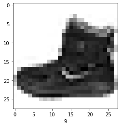

```python
plt.imshow(x_train[0], cmap='binary')
plt.xlabel(y_train[0])
plt.show()
```

```python
x_train.shape
```

```
(60000, 28, 28)
```

```python
def create_model(hp):

  num_hidden_layers = 1
  num_units = 8
  dropout_rate = 0.1
  learning_rate = 0.01

  if hp:
    num_hidden_layers = hp.Choice('num_hidden_layers',values = [1,2,3])
    num_units = hp.Choice('num_untis',values = [8,16,32])
    dropout_rate = hp.Float('dropout_rate',min_value = 0.1,max_value = 0.5,step=0.1)
    learning_rate = hp.Float("learning_rate", 1e-4, 1e-2, sampling="log", default=1e-3)

  model = tf.keras.models.Sequential()

  model.add(tf.keras.layers.Flatten(input_shape = (28,28)))
  model.add(tf.keras.layers.Lambda(lambda x:x/255.))

  for _ in range(0,num_hidden_layers):
    model.add(tf.keras.layers.Dense(num_units,activation='relu'))
    model.add(tf.keras.layers.Dropout(dropout_rate))

  model.add(tf.keras.layers.Dense(10,activation = 'softmax'))

  model.compile(
      loss = tf.keras.losses.SparseCategoricalCrossentropy(from_logits=True),
      optimizer = tf.keras.optimizers.Adam(learning_rate=learning_rate),
      metrics = ['accuracy']
  )

  return model
```

```python
create_model(None).summary()
```

```
Model: "sequential"
_________________________________________________________________
 Layer (type)                Output Shape              Param #
=================================================================
 flatten (Flatten)           (None, 784)               0

 lambda (Lambda)             (None, 784)               0

 dense (Dense)               (None, 8)                 6280

 dropout (Dropout)           (None, 8)                 0

 dense_1 (Dense)             (None, 10)                90

=================================================================
Total params: 6,370
Trainable params: 6,370
Non-trainable params: 0
_________________________________________________________________
```

```python
import keras_tuner
class CustomTuner(keras_tuner.tuners.BayesianOptimization):
  def run_trail(self,trial,*args,**kwargs):
    kwargs['batch_size'] = trial.hyperparameter.Int('batch_size',32,128,step = 16)
    super(CustomTuner,self).run_trail(trial,*args,**kwargs)
```

```python
tuner = CustomTuner(
    create_model,
    objective='val_accuracy',
    max_trials = 2,
    directory='logs',
    project_name = 'fashion_mnist',
    overwrite=True
)
```

```python
tuner.search_space_summary()
```

```
Search space summary
Default search space size: 4
num_hidden_layers (Choice)
{'default': 1, 'conditions': [], 'values': [1, 2, 3], 'ordered': True}
num_untis (Choice)
{'default': 8, 'conditions': [], 'values': [8, 16, 32], 'ordered': True}
dropout_rate (Float)
{'default': 0.1, 'conditions': [], 'min_value': 0.1, 'max_value': 0.5, 'step': 0.1, 'sampling': None}
learning_rate (Float)
{'default': 0.001, 'conditions': [], 'min_value': 0.0001, 'max_value': 0.01, 'step': None, 'sampling': 'log'}
```

```python
tuner.search( x_train,y_train, validation_data = (x_test,y_test), epochs = 5,verbose = True)
```

```
Trial 2 Complete [00h 00m 41s]
val_accuracy: 0.8270000219345093

Best val_accuracy So Far: 0.8270000219345093
Total elapsed time: 00h 01m 22s
INFO:tensorflow:Oracle triggered exit
```

```python
tuner.results_summary(1)
```

```
Results summary
Results in logs/fashion_mnist
Showing 1 best trials
Objective(name='val_accuracy', direction='max')
Trial summary
Hyperparameters:
num_hidden_layers: 1
num_untis: 32
dropout_rate: 0.2
learning_rate: 0.007684305036481918
Score: 0.8270000219345093
```

```python
#Best model so far
model = tuner.get_best_models(num_models = 10)[0]
model.summary()
```

[output not shown]

```python
h = model.fit(
    x_train, y_train,
    validation_data=(x_test, y_test),
    epochs=20, verbose=2,
    batch_size=128,
    callbacks=[
        tf.keras.callbacks.EarlyStopping(monitor='val_accuracy', patience=3)
    ]
)
```

```
469/469 - 2s - loss: 0.5617 - accuracy: 0.7869 - val_loss: 0.4529 - val_accuracy: 0.8427 - 2s/epoch - 4ms/step
469/469 - 2s - loss: 0.5533 - accuracy: 0.7900 - val_loss: 0.4568 - val_accuracy: 0.8426 - 2s/epoch - 3ms/step
469/469 - 1s - loss: 0.5569 - accuracy: 0.7884 - val_loss: 0.4526 - val_accuracy: 0.8442 - 1s/epoch - 3ms/step
469/469 - 1s - loss: 0.5531 - accuracy: 0.7886 - val_loss: 0.4699 - val_accuracy: 0.8388 - 1s/epoch - 3ms/step
469/469 - 1s - loss: 0.5549 - accuracy: 0.7895 - val_loss: 0.4711 - val_accuracy: 0.8386 - 1s/epoch - 3ms/step
469/469 - 2s - loss: 0.5608 - accuracy: 0.7837 - val_loss: 0.4714 - val_accuracy: 0.8384 - 2s/epoch - 3ms/step
```

```python
model.evaluate(x_test,y_test)
```

```
[0.4714382290840149, 0.8384000062942505]
```

## Part 3: Transfer learning (25 marks)

For this part, you can choose any pre-trained network available in [keras.applications](https://keras.io/api/applications/), **except VGG16 or VGG19**. Be sure to verify that the chosen network can be used for classification. Following what we did in class, apply this model, with data augmentation, to the data you created for **Lab 4**. Compare the accuracy on test data to what you achieved in Lab 4.

```python
import os
current_directory = os.getcwd()
current_directory
```

```
'/content'
```

```python
#below code is for saving path for the images
import os
from tensorflow.keras.preprocessing.image import ImageDataGenerator

current_directory = os.getcwd()

Train_Images = '/content/drive/My Drive/Colab Notebooks/Data/Data/train/'
Test_Images = '/content/drive/My Drive/Colab Notebooks/Data/Data/test/'
Validation_Images = '/content/drive/My Drive/Colab Notebooks/Data/Data/validation/'


#here i am dividing the images in 2 classes like horse and not horse
train_horse_image = os.path.join(Train_Images,'horse')
train_not_horse_image = os.path.join(Train_Images,'not_horse')


test_horse_image = os.path.join(Test_Images,'horse')
test_not_horse_image = os.path.join(Test_Images,'not_horse')

valid_horse_image = os.path.join(Validation_Images,'horse')
valid_not_horse_image = os.path.join(Validation_Images,'not_horse')

## horizontal_flip will flip image horizontally, vertical_flip will flip images vertically
image_gen = ImageDataGenerator(rescale = 1./255,
                               horizontal_flip =True,
                               vertical_flip = True,
                               rotation_range = 48,
                               height_shift_range = 0.2,
                               width_shift_range = 0.2,
                               # It will shift image width with given range.
                               brightness_range = [1.0,0.5],
                               fill_mode = 'nearest')

BATCH_SIZE = 32

#data-augmentation parameters to ImageDataGenerator

train_data_gen1 = image_gen.flow_from_directory(batch_size = BATCH_SIZE,
                                                directory = Train_Images,
                                                target_size = (148, 148),
                                                class_mode = 'binary')

test_data_gen1 = image_gen.flow_from_directory(batch_size = BATCH_SIZE,
                                               directory = Test_Images,
                                               target_size = (148, 148),
                                               class_mode = 'binary')

valid_data_gen1 = image_gen.flow_from_directory(batch_size = BATCH_SIZE,
                                                directory = Validation_Images,
                                                target_size = (148, 148),
                                                class_mode = 'binary')
```

```
Found 100 images belonging to 2 classes.
Found 30 images belonging to 1 classes.
Found 30 images belonging to 2 classes.
```

```python
from google.colab import drive
drive.mount('/content/drive')
```

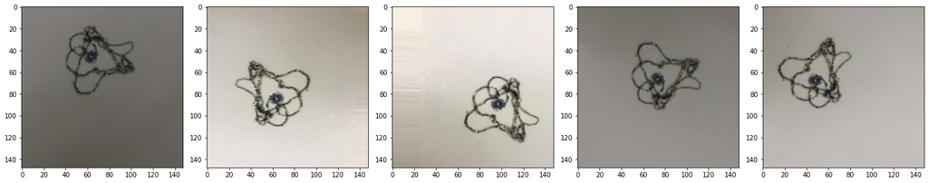

```python
#Data augmentation
#Genrate 3 different plots using 20*20 image size
def plot_Images(x):
    fig, axes = plt.subplots(1, 5, figsize=(20,20))
    axes = axes.flatten()
    for img, ax in zip(x, axes):
        ax.imshow(img)
    plt.tight_layout()
    plt.show()

#flip the image from training dataset
flip = [train_data_gen1[0][0][0] for i in range(5)]
plot_Images(flip)
```

```python
from tensorflow.keras.applications import ResNet50
from tensorflow.keras.applications.resnet50 import preprocess_input
base_model = ResNet50(include_top = False,
                        weights = 'imagenet',
                        pooling = None,
                        input_shape = (148,148,3))

base_model.trainable = False
```

```
Downloading data from https://storage.googleapis.com/tensorflow/keras-applications/resnet/resnet50_weights_tf_dim_ordering_tf_kernels_notop.h5
```

```python
from tensorflow import keras
from tensorflow.keras import layers

#data augmentation layer
Network_Augmentation = keras.Sequential([layers.RandomFlip("horizontal"),
                                      layers.RandomRotation(0.1),
                                      layers.RandomZoom(0.2)])

inputs = keras.Input(shape=(148, 148, 3))
x = Network_Augmentation(inputs)
x = keras.applications.resnet50.preprocess_input(x)
x = base_model(x)
x = layers.Flatten()(x)
x = layers.Dense(256)(x)
x = layers.Dropout(0.3)(x)
outputs = layers.Dense(132,activation='relu')(x)
outputs = layers.Dense(1, activation="sigmoid")(outputs)

Improved_Network = keras.Model(inputs, outputs)
Improved_Network.summary()
```

```
Model: "model"
_________________________________________________________________
 Layer (type)                Output Shape              Param #
=================================================================
 input_2 (InputLayer)        [(None, 148, 148, 3)]     0

 sequential_1 (Sequential)   (None, 148, 148, 3)       0

 tf.__operators__.getitem (S  (None, 148, 148, 3)      0
 licingOpLambda)

 tf.nn.bias_add (TFOpLambda)  (None, 148, 148, 3)      0

 resnet50 (Functional)       (None, 5, 5, 2048)        23587712

 flatten_1 (Flatten)         (None, 51200)             0

 dense_3 (Dense)             (None, 256)               13107456

 dropout_2 (Dropout)         (None, 256)               0

 dense_4 (Dense)             (None, 132)               33924

 dense_5 (Dense)             (None, 1)                 133

=================================================================
Total params: 36,729,225
Trainable params: 13,141,513
Non-trainable params: 23,587,712
_________________________________________________________________
```

```python
Improved_Network.compile(loss="binary_crossentropy", optimizer="adam", metrics=["accuracy"])

#callbacks
callbacks = keras.callbacks.ModelCheckpoint(filepath = "feature_extraction_with_data_augmentation.keras",
                                            save_best_only = True, monitor = "val_loss")

#fit the model
history_3 = Improved_Network.fit(train_data_gen1,
                                 epochs=10,
                                 validation_data = valid_data_gen1,
                                 callbacks=[callbacks])
```

[output not shown]

```python
base_model_test_loss, base_model_test_accuracy = Improved_Network.evaluate_generator(generator = test_data_gen1)
print("Test loss is ", base_model_test_loss)
print("Test accuracy is", base_model_test_accuracy)
```

```
Test loss is  0.14114494621753693
Test accuracy is 1.0
```

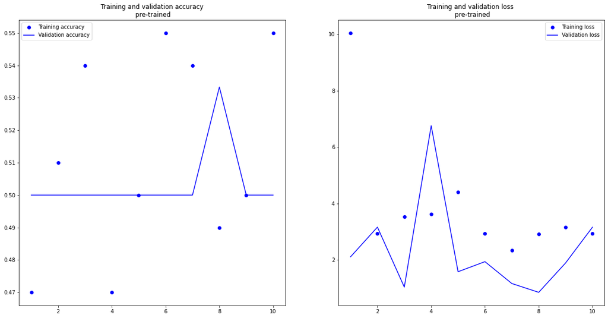

```python
accuracy = history_3.history["accuracy"]
val_accuracy = history_3.history["val_accuracy"]
loss = history_3.history["loss"]
val_loss = history_3.history["val_loss"]
epochs = range(1, len(accuracy) + 1)

plt.figure(figsize=(20, 10))

plt.subplot(1, 2, 1)
plt.plot(epochs, accuracy, "bo", label="Training accuracy")
plt.plot(epochs, val_accuracy, "b", label="Validation accuracy")
plt.title("Training and validation accuracy\n pre-trained")
plt.legend()

plt.subplot(1, 2, 2)
plt.plot(epochs, loss, "bo", label="Training loss")
plt.plot(epochs, val_loss, "b", label="Validation loss")
plt.title("Training and validation loss \n pre-trained")
plt.legend()
plt.show()
```

**Part 4: Fine-tuning (25 marks)**

Following what we did in class, fine-tune the model that you trained in Part 3. Compare the accuracy on test data to what you achieved in Part 3.

```python
base_model.trainable = True
base_model.summary()
```

```
Model: "resnet50"
__________________________________________________________________________________________________
 Layer (type)                   Output Shape         Param #     Connected to
==================================================================================================
 input_1 (InputLayer)           [(None, 148, 148, 3  0           []
                                )]

 conv1_pad (ZeroPadding2D)      (None, 154, 154, 3)  0           ['input_1[0][0]']

 conv1_conv (Conv2D)            (None, 74, 74, 64)   9472        ['conv1_pad[0][0]']

 conv1_bn (BatchNormalization)  (None, 74, 74, 64)   256         ['conv1_conv[0][0]']

 conv1_relu (Activation)        (None, 74, 74, 64)   0           ['conv1_bn[0][0]']

 pool1_pad (ZeroPadding2D)      (None, 76, 76, 64)   0           ['conv1_relu[0][0]']

 pool1_pool (MaxPooling2D)      (None, 37, 37, 64)   0           ['pool1_pad[0][0]']

 conv2_block1_1_conv (Conv2D)   (None, 37, 37, 64)   4160        ['pool1_pool[0][0]']

 conv2_block1_1_bn (BatchNormal  (None, 37, 37, 64)  256         ['conv2_block1_1_conv[0][0]']
 ization)

 conv2_block1_1_relu (Activatio  (None, 37, 37, 64)  0           ['conv2_block1_1_bn[0][0]']
 n)

 conv2_block1_2_conv (Conv2D)   (None, 37, 37, 64)   36928       ['conv2_block1_1_relu[0][0]']

 conv2_block1_2_bn (BatchNormal  (None, 37, 37, 64)  256         ['conv2_block1_2_conv[0][0]']
 ization)

 conv2_block1_2_relu (Activatio  (None, 37, 37, 64)  0           ['conv2_block1_2_bn[0][0]']
 n)

 conv2_block1_0_conv (Conv2D)   (None, 37, 37, 256)  16640       ['pool1_pool[0][0]']

 conv2_block1_3_conv (Conv2D)   (None, 37, 37, 256)  16640       ['conv2_block1_2_relu[0][0]']

 conv2_block1_0_bn (BatchNormal  (None, 37, 37, 256)  1024       ['conv2_block1_0_conv[0][0]']
```

[output cut: 418 more lines]

```
 conv5_block3_3_conv (Conv2D)   (None, 5, 5, 2048)   1050624     ['conv5_block3_2_relu[0][0]']

 conv5_block3_3_bn (BatchNormal  (None, 5, 5, 2048)  8192        ['conv5_block3_3_conv[0][0]']
 ization)

 conv5_block3_add (Add)         (None, 5, 5, 2048)   0           ['conv5_block2_out[0][0]',
                                                                  'conv5_block3_3_bn[0][0]']

 conv5_block3_out (Activation)  (None, 5, 5, 2048)   0           ['conv5_block3_add[0][0]']

==================================================================================================
Total params: 23,587,712
Trainable params: 23,534,592
Non-trainable params: 53,120
__________________________________________________________________________________________________
```

```python
#setting the base_model layers
for layer in base_model.layers[:-2]:
    layer.trainable=False

for layer in base_model.layers:
    print(f"Is layer {layer.name} trainable? {layer.trainable}")

base_model.summary()

#recompiled and trained the model from the last section
Improved_Network.compile(optimizer=keras.optimizers.RMSprop(learning_rate=1e-5),
              loss="binary_crossentropy",
              metrics=["accuracy"])

#created call backs
callbacks = keras.callbacks.ModelCheckpoint(filepath="fine_tuning.keras",
                                            save_best_only=True,
                                            monitor="val_loss")

#fitted the model on our data
history_aug = Improved_Network.fit(train_data_gen1,
                                   epochs=10,
                                   validation_data = valid_data_gen1,
                                   callbacks=[callbacks])
```

```
Is layer input_1 trainable? False
Is layer conv1_pad trainable? False
Is layer conv1_conv trainable? False
Is layer conv1_bn trainable? False
Is layer conv1_relu trainable? False
Is layer pool1_pad trainable? False
Is layer pool1_pool trainable? False
Is layer conv2_block1_1_conv trainable? False
Is layer conv2_block1_1_bn trainable? False
Is layer conv2_block1_1_relu trainable? False
Is layer conv2_block1_2_conv trainable? False
Is layer conv2_block1_2_bn trainable? False
Is layer conv2_block1_2_relu trainable? False
Is layer conv2_block1_0_conv trainable? False
Is layer conv2_block1_3_conv trainable? False
Is layer conv2_block1_0_bn trainable? False
Is layer conv2_block1_3_bn trainable? False
Is layer conv2_block1_add trainable? False
Is layer conv2_block1_out trainable? False
Is layer conv2_block2_1_conv trainable? False
Is layer conv2_block2_1_bn trainable? False
Is layer conv2_block2_1_relu trainable? False
Is layer conv2_block2_2_conv trainable? False
Is layer conv2_block2_2_bn trainable? False
Is layer conv2_block2_2_relu trainable? False
Is layer conv2_block2_3_conv trainable? False
Is layer conv2_block2_3_bn trainable? False
Is layer conv2_block2_add trainable? False
Is layer conv2_block2_out trainable? False
Is layer conv2_block3_1_conv trainable? False
Is layer conv2_block3_1_bn trainable? False
Is layer conv2_block3_1_relu trainable? False
Is layer conv2_block3_2_conv trainable? False
Is layer conv2_block3_2_bn trainable? False
Is layer conv2_block3_2_relu trainable? False
Is layer conv2_block3_3_conv trainable? False
Is layer conv2_block3_3_bn trainable? False
Is layer conv2_block3_add trainable? False
Is layer conv2_block3_out trainable? False
Is layer conv3_block1_1_conv trainable? False
```

[output cut: 593 more lines]

```
 conv5_block3_3_conv (Conv2D)   (None, 5, 5, 2048)   1050624     ['conv5_block3_2_relu[0][0]']

 conv5_block3_3_bn (BatchNormal  (None, 5, 5, 2048)  8192        ['conv5_block3_3_conv[0][0]']
 ization)

 conv5_block3_add (Add)         (None, 5, 5, 2048)   0           ['conv5_block2_out[0][0]',
                                                                  'conv5_block3_3_bn[0][0]']

 conv5_block3_out (Activation)  (None, 5, 5, 2048)   0           ['conv5_block3_add[0][0]']

==================================================================================================
Total params: 23,587,712
Trainable params: 0
Non-trainable params: 23,587,712
__________________________________________________________________________________________________
```

```python
print("Evaluating the model on test data:")
test_model = keras.models.load_model("fine_tuning.keras")
test_loss, test_acc = test_model.evaluate(test_data_gen1)

print(f"Test accuracy: {test_acc:.3f}")
```

```
Evaluating the model on test data:
```

```
Test accuracy: 1.000
```

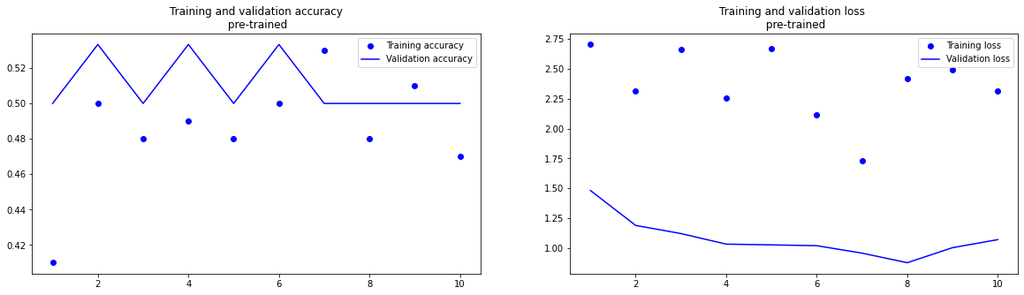

```python
accuracy = history_aug.history["accuracy"]
val_accuracy = history_aug.history["val_accuracy"]
loss = history_aug.history["loss"]
val_loss = history_aug.history["val_loss"]
epochs = range(1, len(accuracy) + 1)

plt.figure(figsize=(20, 5))

plt.subplot(1, 2, 1)
plt.plot(epochs, accuracy, "bo", label="Training accuracy")
plt.plot(epochs, val_accuracy, "b", label="Validation accuracy")
plt.title("Training and validation accuracy\n pre-trained")
plt.legend()

plt.subplot(1, 2, 2)
plt.plot(epochs, loss, "bo", label="Training loss")
plt.plot(epochs, val_loss, "b", label="Validation loss")
plt.title("Training and validation loss \n pre-trained")
plt.legend()
plt.show()
```

**Compare**

Lab 4

Validation Accuracy:- 60 Test Accuracy:- 74